# UD_DataWrangle_Project

## OpenStreetMap Data Case Study using MongoDB

### Map Area : Singapore

This dataset was chosen because this is the where I've called home for the last nine years. So it should be interesting to see how well maintained is the data in OSM for this country and if this analysis will be able to uncover any mistakes that is worth fixing.

Also I've just learn about how useful OpenStreetMap can be especially during crisis, such as the Haitian earthquake where the maps were used to map to new roads in the disaster area to map shortest routes towards help, drinking water, resources, etc. Thus it's definitely a good tool to learn.

1. https://www.openstreetmap.org/relation/536780
2. https://mapzen.com/data/metro-extracts/metro/singapore/

#### References:

1. https://review.udacity.com/#!/rubrics/25/view
2. https://docs.google.com/document/d/1F0Vs14oNEs2idFJR3C_OPxwS6L0HPliOii-QpbmrMo4/pub
3. https://gist.github.com/carlward/54ec1c91b62a5f911c42#file-sample_project-md
4. https://www.youtube.com/watch?v=d6n29CU2-Sg
5. https://www.openstreetmap.org/welcome
6. https://github.com/jasonicarter/DAND_OpenStreetMap_Data_MongoDB/blob/master/OpenStreetMap_Data_MongoDB.ipynb
7. https://gis.stackexchange.com/questions/171149/link-between-node-building-street-in-osm
8. https://stackoverflow.com/questions/2896752/removing-item-from-list-during-iteration-whats-wrong-with-this-idiom
9. https://code.activestate.com/recipes/577081-humanized-representation-of-a-number-of-bytes/
10. http://sethlui.com/best-bak-kut-teh-singapore/

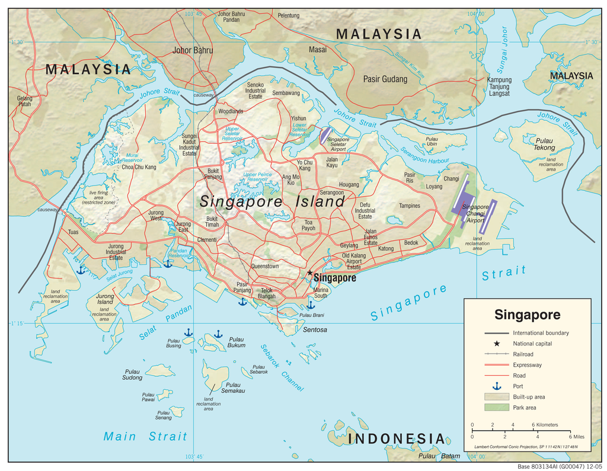

```python
from IPython.display import Image
Image("https://www.lib.utexas.edu/maps/middle_east_and_asia/singapore_physio-2005.jpg", width ="600")
```

```python
#!/usr/bin/env python
# -*- coding: utf-8 -*-

'''
Use the following code to take a systematic sample of elements from your original OSM region.
Try changing the value of k so that your resulting SAMPLE_FILE ends up at different sizes.
When starting out, try using a larger k, then move on to an intermediate k before processing your whole dataset.
'''

import xml.etree.ElementTree as ET  # Use cElementTree or lxml if too slow

OSM_FILE = "singapore.osm"  # Replace this with your osm file
SAMPLE_FILE = "sample.osm"

k = 100 # Parameter: take every k-th top level element

def get_element(osm_file, tags=('node', 'way', 'relation')):
    """Yield element if it is the right type of tag

    Reference:
    http://stackoverflow.com/questions/3095434/inserting-newlines-in-xml-file-generated-via-xml-etree-elementtree-in-python
    """
    context = iter(ET.iterparse(osm_file, events=('start', 'end')))
    _, root = next(context)
    for event, elem in context:
        if event == 'end' and elem.tag in tags:
            yield elem
            root.clear()

def create_samplefile():
    with open(SAMPLE_FILE, 'wb') as output:
        output.write('<?xml version="1.0" encoding="UTF-8"?>\n')
        output.write('<osm>\n  ')

        # Write every kth top level element
        for i, element in enumerate(get_element(OSM_FILE)):
            if i % k == 0:
                output.write(ET.tostring(element, encoding='utf-8'))

        output.write('</osm>')

# Comment it out to avoid accidental run of this program
#create_samplefile()
```

### Data Audit

As suggested by the project instruction, I've created a sample dataset to randomly check through for problematic data first. This part also involces creating json files (a lot of code reuse from the previous MongoDB project) and loading them into a mongoDB database for further querying. Based on the sample projects, a few key things to explore would be:

1. Incorrect postal code
2. Abbrevation used in the road names or building name
3. Inconsistencies on other part of the address

So let's begin checking on these three items and see what other issues I can find based on the Singapore sample dataset.

```python
#!/usr/bin/env python
# -*- coding: utf-8 -*-
import xml.etree.cElementTree as ET
import pprint
import re
import codecs
import json
import collections

address_type_direction = re.compile(r'^addr:[a-z]+:[a-z]+$')
address = re.compile(r'^addr:[a-z]+$')
lower = re.compile(r'^([a-z]|_)*$')
lower_colon = re.compile(r'^([a-z]|_)*:([a-z]|_)*$')
problemchars = re.compile(r'[=\+/&<>;\'"\?%#$@\,\. \t\r\n]')
ignored_regexs = [problemchars, address_type_direction]

my_postcode_format = re.compile(r'^[0-9]{5}$')


CREATED = [ "version", "changeset", "timestamp", "user", "uid"]
SUBMAPPING = {"addr":"address"}

def process_refs(node, element):
    refs = []
    for nodes in element.iter('nd'):
        ref = long(nodes.attrib["ref"])
        refs.append(ref)
        #print (ref)

    if refs:
        node["node_refs"] = refs

    return node

def process_tags(node, element):
    tagvalues = []
    for tags in element.iter('tag'):
        #print tags.attrib
        attribk = tags.attrib["k"]
        if any(regex.search(attribk) for regex in ignored_regexs):
            #do nothing
            continue
        elif address.search(attribk) or lower_colon.search(attribk):
            addressparts = attribk.split(":")

            # differentiate between addr and the rest of the other sub tags
            if addressparts[0] in SUBMAPPING.keys():
                keyword = SUBMAPPING[addressparts[0]]
            else:
                keyword = addressparts[0]

            # add an additional check here to skip nodes / ways with Malaysian's postcode
            attr_key = addressparts[1]
            attr_value = tags.attrib["v"]

            tagvalues.append([keyword, attr_key, attr_value])
            #print ([keyword, addressparts[1], tags.attrib["v"]])

        else:
            node[attribk] = tags.attrib["v"]

    # append each sub tag back to the main node
    tagdict = {}
    for maintag, k, v in tagvalues:
        tagdict.setdefault(maintag, {})[k] = v

    for k,v in tagdict.iteritems():
        node[k] = v

    return node

def shape_element(element):
    node = {}
    if element.tag == "node" or element.tag == "way" :
        node["type"] = element.tag
        createddict = {}
        pos = [0, 0]
        for k,v in element.attrib.iteritems():
            if k in CREATED:
                createddict[k] = v
            elif k == "lat":
                pos[0] = float(v)
            elif k == "lon":
                pos[1] = float(v)
            else:
                node[k] = v

        node["created"] = createddict
        node["pos"] = pos

        node = process_tags(node, element)

        node = process_refs(node, element)

        return node
    else:
        return None

def process_map(file_in, pretty = False):
    file_out = "{0}.json".format(file_in)
    data = []
    with codecs.open(file_out, "w") as fo:
        for _, element in ET.iterparse(file_in):
            el = shape_element(element)
            if el:
                data.append(el)
                if pretty:
                    fo.write(json.dumps(el, indent=2)+"\n")
                else:
                    fo.write(json.dumps(el) + "\n")
    return data

def main():
    # NOTE: if you are running this code on your computer, with a larger dataset,
    # call the process_map procedure with pretty=False. The pretty=True option adds
    # additional spaces to the output, making it significantly larger.
    data = process_map('sample.osm', True)
    pprint.pprint(data[0])

if __name__ == "__main__":
    main()
```

```
{'created': {'changeset': '45574817',
             'timestamp': '2017-01-27T21:07:37Z',
             'uid': '126508',
             'user': 'Canyonsrcool',
             'version': '6'},
 'id': '25451905',
 'pos': [1.3504416, 103.9857773],
 'type': 'node'}
```

### Load DB using terminal

Instead of running the data import using python script, a more efficient way is via the mongoimport command line which can better handle the import of larger files. Hence that's the chosen steps that we will follow to import the OSM data into our mongo database.

mongo sample --eval "db.dropDatabase()"

mongoimport --db sample --collection osm --file /Users/stevetan/Dropbox/0udacity/data\ analyst\ nanodegree/datawrangling/project/sample.osm.json

```python
def run_aggregate_result(pipeline, db):
    results = db.osm.aggregate(pipeline)
    #print type(results)

    import pprint
    for result in results:
        pprint.pprint(result)
```

```python
from pymongo import MongoClient
client = MongoClient("mongodb://localhost:27017")
db = client.sample

project = {"$project":
          {"postcode":"$address.postcode", "_id":0}
          }
match = {"$match":
          {"address.postcode" : {"$exists":"true"}}
         }
pipeline = [match, project]
run_aggregate_result(pipeline, db)
```

```
{u'postcode': u'81300'}
{u'postcode': u'688688'}
{u'postcode': u'408727'}
{u'postcode': u'068726'}
{u'postcode': u'069461'}
{u'postcode': u'089138'}
{u'postcode': u'098269'}
{u'postcode': u'168727'}
{u'postcode': u'398738'}
{u'postcode': u'209178'}
{u'postcode': u'058818'}
{u'postcode': u'119599'}
{u'postcode': u'267208'}
{u'postcode': u'118260'}
{u'postcode': u'350121'}
{u'postcode': u'039594'}
{u'postcode': u'81100'}
{u'postcode': u'179803'}
{u'postcode': u'790437'}
{u'postcode': u'247933'}
{u'postcode': u'519634'}
{u'postcode': u'228208'}
{u'postcode': u'678213'}
{u'postcode': u'538692'}
{u'postcode': u'239917'}
{u'postcode': u'048659'}
{u'postcode': u'117611'}
{u'postcode': u'520232'}
{u'postcode': u'520264'}
{u'postcode': u'520487'}
{u'postcode': u'520447'}
{u'postcode': u'521164'}
{u'postcode': u'556113'}
{u'postcode': u'109918'}
{u'postcode': u'560431'}
{u'postcode': u'560564'}
{u'postcode': u'560573'}
{u'postcode': u'640854'}
{u'postcode': u'470615'}
{u'postcode': u'<different>'}
```

[output cut: 179 more lines]

```
{u'postcode': u'80350'}
{u'postcode': u'80350'}
{u'postcode': u'80350'}
{u'postcode': u'81200'}
{u'postcode': u'80250'}
{u'postcode': u'80350'}
{u'postcode': u'80350'}
{u'postcode': u'80350'}
{u'postcode': u'792445'}
{u'postcode': u'350138'}
{u'postcode': u'509067'}
{u'postcode': u'398693'}
{u'postcode': u'350130'}
{u'postcode': u'81700'}
{u'postcode': u'81700'}
```

```python
match = {"$match":
          {"$or": [{"address.postcode" : "81300"},{"address.postcode" : "688688"}
                   ,{"address.postcode" : "<different>"}]}
         }
project = {"$project":
          {"address":"$address", "_id":0}
          }
sort = {"$sort": {"count" : -1}}
group = { "$group": { "_id": "$address",
                      "count": {"$sum":1}}}
pipeline = [match, project, group, sort]
run_aggregate_result(pipeline, db)
```

```
{u'_id': {u'city': u'Singapore',
          u'country': u'SG',
          u'housenumber': u'60',
          u'postcode': u'<different>',
          u'street': u'Tuas Avenue 11'},
 u'count': 1}
{u'_id': {u'country': u'SG',
          u'housenumber': u'3',
          u'postcode': u'688688',
          u'street': u'Verde View'},
 u'count': 1}
{u'_id': {u'housenumber': u'23',
          u'postcode': u'81300',
          u'street': u'Jalan Seri Impian 1, Taman Impian Emas,'},
 u'count': 1}
```

### Problems encountered in the Map

#### Incorrect postal code

```python
project = {"$project":
          {"street":"$address.street","_id":0}
          }
match = {"$match":
          {"$and":[{"address.street" : {"$exists":"true"}},{"address.postcode":{"$regex":"[0-9]{6}"}} ]}
         }
sort = {"$sort": {"count" : -1}}
group = { "$group": { "_id": "$street",
                    "count": {"$sum":1}}}
pipeline = [match, project, sort, group]
run_aggregate_result(pipeline, db)
```

```
{u'_id': u'Loyang Avenue', u'count': 1}
{u'_id': u'Potong Pasir Avenue 3', u'count': 1}
{u'_id': u'Sin Ming Road', u'count': 1}
{u'_id': u'Compassvale Bow', u'count': 1}
{u'_id': u'Pine Grove', u'count': 1}
{u'_id': u'Pasir Ris Drive 6', u'count': 1}
{u'_id': u'Bukit Batok West Avenue 5', u'count': 1}
{u'_id': u'Ang Mo Kio Avenue 8', u'count': 1}
{u'_id': u'Tampines Street 71', u'count': 1}
{u'_id': u'Duxton Hill', u'count': 1}
{u'_id': u'Waterloo Street', u'count': 1}
{u'_id': u'Paya Lebar Way', u'count': 1}
{u'_id': u'Redhill Lane', u'count': 1}
{u'_id': u'Pasir Ris Drive 1', u'count': 1}
{u'_id': u'Pasir Ris Street 53', u'count': 1}
{u'_id': u'Bukit Batok Central', u'count': 1}
{u'_id': u'Bukit Batok Street 31', u'count': 1}
{u'_id': u'Bukit Batok East Avenue 4', u'count': 1}
{u'_id': u'Jalan Tari Zapin', u'count': 1}
{u'_id': u'Mimosa Walk', u'count': 1}
{u'_id': u'Tampines Street 21', u'count': 1}
{u'_id': u'Mimosa Vale', u'count': 1}
{u'_id': u'Mimosa Terrace', u'count': 1}
{u'_id': u'Saraca Road', u'count': 1}
{u'_id': u'Begonia Drive', u'count': 2}
{u'_id': u'Tampines Street 42', u'count': 1}
{u'_id': u'Upper Neram Road', u'count': 1}
{u'_id': u'Pasir Ris Street 72', u'count': 1}
{u'_id': u'Dedap Link', u'count': 1}
{u'_id': u'Tamarind Road', u'count': 4}
{u'_id': u'Saraca Terrace', u'count': 1}
{u'_id': u'Heng Mui Keng Terrace', u'count': 1}
{u'_id': u'Dedap Road', u'count': 1}
{u'_id': u'Bedok Reservoir Road', u'count': 1}
{u'_id': u'Jurong West Street 81', u'count': 1}
{u'_id': u'Bukit Chermin Road', u'count': 1}
{u'_id': u'Tampines Street 12', u'count': 1}
{u'_id': u'Simei Street 4', u'count': 1}
{u'_id': u'Pickering Street', u'count': 1}
{u'_id': u'Bukit Batok Street 32', u'count': 1}
```

[output cut: 24 more lines]

```
{u'_id': u'Science Park Road', u'count': 1}
{u'_id': u'Verde View', u'count': 1}
{u'_id': u'Namly Place', u'count': 1}
{u'_id': u'Ubi Road 1', u'count': 1}
{u'_id': u'Ocean Drive', u'count': 1}
{u'_id': u'Club Street', u'count': 2}
{u'_id': u'Hougang Street 91', u'count': 1}
{u'_id': u'Serangoon Avenue 3', u'count': 1}
{u'_id': u'Tampines Avenue 9', u'count': 1}
{u'_id': u'Stanley Street', u'count': 1}
{u'_id': u'Neram Road', u'count': 1}
{u'_id': u'Ang Mo Kio Avenue 3', u'count': 1}
{u'_id': u'Science Park Drive', u'count': 1}
{u'_id': u'Kaki Bukit Road 3', u'count': 1}
{u'_id': u'South Bridge Road', u'count': 1}
```

### Problems encountered in the Map 2

#### Abbrevation used in the road names or building name

1. Road names - the road names here doesn't show any issue of inconsistencies due the lack of of abbreviation usage.
   1. A check through the common abbrevation found such as street, avenue, drive or road are fully spelled out in the street names.
   2. Hence no further work is required to clean this part up.

```python
project = {"$project":
          {"address":"$address", "_id": 0}
          }
match = {"$match":
          {"address" : {"$exists":"true"}}
         }
pipeline = [match, project]
run_aggregate_result(pipeline, db)
```

```
{u'address': {u'housenumber': u'1C'}}
{u'address': {u'housenumber': u'8'}}
{u'address': {u'housenumber': u'23',
              u'postcode': u'81300',
              u'street': u'Jalan Seri Impian 1, Taman Impian Emas,'}}
{u'address': {u'housename': u'Hilton Hotel Lobby'}}
{u'address': {u'street': u'Geylang East Avenue'}}
{u'address': {u'country': u'SG',
              u'housenumber': u'3',
              u'postcode': u'688688',
              u'street': u'Verde View'}}
{u'address': {u'street': u'Joo Chiat Road'}}
{u'address': {u'city': u'Singapore',
              u'housenumber': u'61',
              u'postcode': u'408727',
              u'street': u'Ubi Road 1'}}
{u'address': {u'city': u'Singapore',
              u'country': u'SG',
              u'housenumber': u'7',
              u'postcode': u'068726',
              u'street': u'Stanley Street'}}
{u'address': {u'city': u'Singapore',
              u'country': u'SG',
              u'housenumber': u'93',
              u'postcode': u'069461',
              u'street': u'Club Street'}}
{u'address': {u'city': u'Singapore',
              u'country': u'SG',
              u'housenumber': u'31',
              u'postcode': u'089138',
              u'street': u'Keong Saik Road'}}
{u'address': {u'housenumber': u'5', u'street': u'Coleman Street'}}
{u'address': {u'city': u'Singapore',
              u'housenumber': u'8',
              u'postcode': u'098269',
              u'street': u'Sentosa Gateway'}}
{u'address': {u'housenumber': u'3', u'street': u'Weyhill Close'}}
{u'address': {u'city': u'Singapore',
              u'country': u'SG',
              u'housenumber': u'77',
```

[output cut: 1268 more lines]

```
{u'address': {u'street': u'Punggol Central'}}
{u'address': {u'street': u'Upper Serangoon Road'}}
{u'address': {u'housenumber': u'31', u'street': u'Carisbrooke Grove'}}
{u'address': {u'housenumber': u'57', u'street': u'Li Hwan Drive'}}
{u'address': {u'housenumber': u'76', u'street': u'Coronation Road'}}
{u'address': {u'city': u'Pasir Gudang',
              u'postcode': u'81700',
              u'street': u'Jalan Dahlia 6'}}
{u'address': {u'city': u'Pasir Gudang',
              u'postcode': u'81700',
              u'street': u'Jalan Semerbak 1'}}
{u'address': {u'city': u'Singapore',
              u'country': u'SG',
              u'housenumber': u'431',
              u'street': u'Fernvale Link'}}
```

```python
result = db.osm.find_one({"address.housenumber":"58"})
pprint.pprint(result)

result = db.osm.find_one({"address.housename":"XB1"})
pprint.pprint(result)
```

```
{u'_id': ObjectId('59dd565e3a5ad6fa007e3330'),
 u'address': {u'housenumber': u'58'},
 u'building': u'yes',
 u'created': {u'changeset': u'19508643',
              u'timestamp': u'2013-12-18T02:43:51Z',
              u'uid': u'741163',
              u'user': u'JaLooNz',
              u'version': u'2'},
 u'id': u'171633825',
 u'node_refs': [1826326467,
                1826326424,
                1826326478,
                1826326466,
                1826326427,
                1826326454,
                1826326467],
 u'pos': [0, 0],
 u'type': u'way'}
{u'_id': ObjectId('59dd565e3a5ad6fa007e32ce'),
 u'address': {u'housename': u'XB1'},
 u'building': u'apartments',
 u'created': {u'changeset': u'15169915',
              u'timestamp': u'2013-02-26T07:24:36Z',
              u'uid': u'1234259',
              u'user': u'UTM_AdamZul',
              u'version': u'3'},
 u'id': u'161046434',
 u'name': u'KDOJ Block XB1',
 u'node_refs': [1730485229,
                1730485292,
                1730485264,
                1730485228,
                1730485075,
                1730485035,
                1730485229],
 u'pos': [0, 0],
 u'type': u'way'}
```

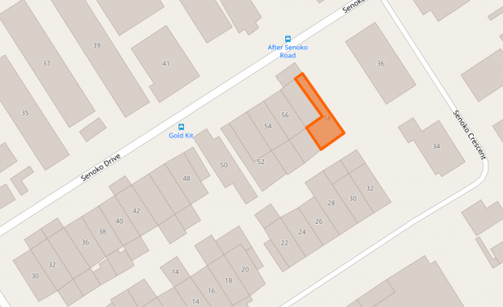

```python
# https://www.openstreetmap.org/way/171633825
url = "https://preview.ibb.co/cUWtLb/Screen_Shot_2017_10_07_at_7_36_40_AM.png"

from IPython.display import Image
Image(url, width ="600")
```

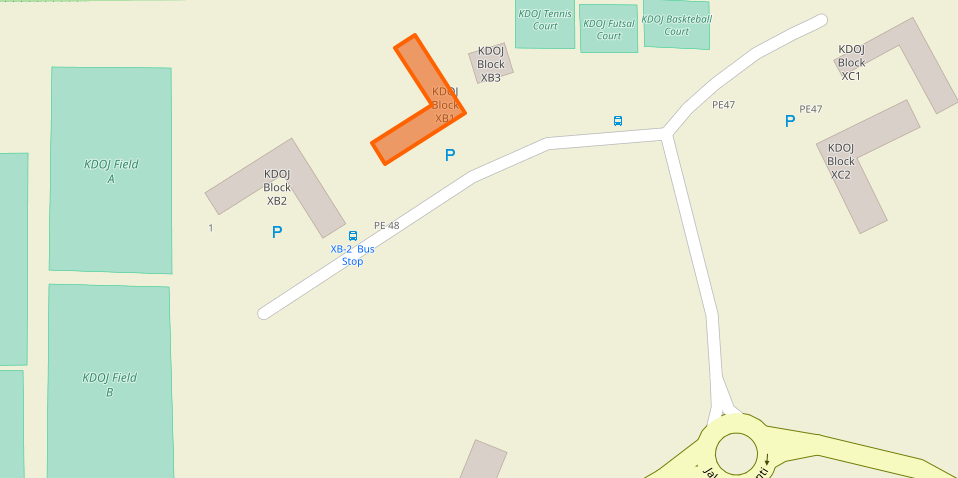

```python
# https://www.openstreetmap.org/way/161046434
url = "https://image.ibb.co/mho9RG/Screen_Shot_2017_10_07_at_9_56_21_AM.png"

from IPython.display import Image
Image(url, width ="600")
```

### Problems encountered in the Map 3

#### Inconsistencies on other part of the address

1. Incomplete addresses - Certain way tags were used to label building but no address details were given, only house number or house name was given.
   1. Using the way id to check back on the OSM website, we can see that it's actually used to label building but the full address which includes the street name and postcode was not given. The house number 58 marks the building but there's no additional details such as postcode or street name was given.
   2. This issue also affects the map for the neighbouring country as can be seen on the way id 161046434. This present a new issue as without the postcode, we wouldn't be able to safely remove and keep only the addresses found in Singapore.

#### Notes

A premature attempt to derive the nearby location using the node reference to determine the max and min of a particular location didn't even come close, hence the node reference is not similar to node positions that we can use to find nearby objects. This was crossed checked using the building name for way id, 54518333, to match back with the building name + street name of the previous house number 58 which is without a address. Based on the map, unfortunately the two points were nowhere near each other. Hence still pending for a better solution to resolve this programatically.

[figure not shown]

```python
# https://www.openstreetmap.org/way/171633825
url = "https://preview.ibb.co/bTXpWG/Screen_Shot_2017_10_13_at_7_11_04_AM.png"

from IPython.display import Image
Image(url, width ="600")
```

```python
# check if we're able to pull address near to house number 58 using node ref
project = {"$project":
          {"address":"$address", "id":"$id", "type":"$type"}
          }
match = {"$match":
          {"$and":[{"address" : {"$exists":"true"}},
                   {"node_refs":{"$gte":1826326424}}, {"node_refs":{"$lte":1826326478}} ]}
         }
pipeline = [match, project]
run_aggregate_result(pipeline, db)
```

```
{u'_id': ObjectId('59dd565e3a5ad6fa007e3155'),
 u'address': {u'housenumber': u'31',
              u'postcode': u'117611',
              u'street': u'Science Park Road'},
 u'id': u'54518333',
 u'type': u'way'}
{u'_id': ObjectId('59dd565e3a5ad6fa007e31c5'),
 u'address': {u'city': u'Singapore',
              u'country': u'SG',
              u'housenumber': u'415',
              u'street': u'Jurong West Street 42'},
 u'id': u'96170575',
 u'type': u'way'}
{u'_id': ObjectId('59dd565e3a5ad6fa007e31d2'),
 u'address': {u'city': u'Singapore',
              u'country': u'SG',
              u'postcode': u'109918',
              u'street': u'Bukit Chermin Road'},
 u'id': u'96923121',
 u'type': u'way'}
{u'_id': ObjectId('59dd565e3a5ad6fa007e3231'),
 u'address': {u'city': u'Johor Bahru',
              u'postcode': u'80250',
              u'street': u'Jalan Geronggang'},
 u'id': u'121970229',
 u'type': u'way'}
{u'_id': ObjectId('59dd565e3a5ad6fa007e3246'),
 u'address': {u'city': u'Singapore',
              u'housenumber': u'43',
              u'street': u'Changi South Avenue 2'},
 u'id': u'124505368',
 u'type': u'way'}
{u'_id': ObjectId('59dd565e3a5ad6fa007e328a'),
 u'address': {u'city': u'Singapore',
              u'country': u'SG',
              u'housenumber': u'20',
              u'postcode': u'737924',
              u'street': u'Woodlands Drive 17'},
 u'id': u'154169603',
 u'type': u'way'}
```

[output cut: 15 more lines]

```
 u'address': {u'city': u'Johor Bahru',
              u'postcode': u'80250',
              u'street': u'Jalan Cenderamata'},
 u'id': u'274199270',
 u'type': u'way'}
{u'_id': ObjectId('59dd565e3a5ad6fa007e35be'),
 u'address': {u'housenumber': u'01-32/33'},
 u'id': u'362268148',
 u'type': u'way'}
{u'_id': ObjectId('59dd565e3a5ad6fa007e3691'),
 u'address': {u'city': u'Johor Bahru',
              u'postcode': u'81200',
              u'street': u'Jalan Dato Abdul Hamid'},
 u'id': u'398918775',
 u'type': u'way'}
```

### Data Cleaning

So we've encountered two issues from checking the sample data set as follows:

1. Some of the addresses in this data set contains the information from a neighbouring country.
   1. We can remove those addresses with a postal code which aren't in a six digits format.
   2. But how do we remove those node and ways that are without a postcode?
2. Certain address for the way contains only a house name or house number, so how do we add address or postcode information to those way?

#### Proposed solution:

1. So based on the scope of this project, we will remove those nodes or ways which aren't in the correct Singapore postcode format to resolve the first issue partially.
2. As for the second problem, I wasn't able to find a programmatic solution on how to map the node or way to a nearby entity to retrieve the street name or postcode.
   1. According to the additional references, we would need to have the relations element defined which properly capture down this information. As these elements cannot be found on those nodes or ways, there's limited steps that we can take here.
   2. So for now, it would be needed to have additional help to get someone to physically map those points and provide the information in.

#### Note

The current data cleaning solution has much room for improvement due to the data clean up only happens after the initial json data was generated from OSM. This creates quite a overhead because the OSM files are rather large and it would require two process run to generate the json for the original osm file and another run to clean up the data to generate a second cleanset json file.

```python
sg_postcode_format = re.compile(r'^[0-9]{6}$')
my_postcode_format = re.compile(r'^[0-9]{5}$')

def update_data(data):
    for row in data[:]:
        if "address" in row.keys():
            if "postcode" in row["address"].keys():
                postcode = row["address"]["postcode"]
                # remove the Malaysian cities information
                if (my_postcode_format.search(postcode)):
                    data.remove(row)
                # remove postcode for cases like <different>
                elif not (sg_postcode_format.search(postcode)):
                    del row["address"]["postcode"]
    return data

def write_to_jsonfile(file_out,data):
    import json
    with open(file_out, 'w') as outfile:
        for row in data:
            json.dump(row, outfile, indent=2)

def main2():
    filename = 'singapore.osm'
    data2 = process_map(filename, True)
    data2 = update_data(data2)

    write_to_jsonfile(filename + "2.json", data2)

# comment it out to avoid accidental run
#main2()
```

#### Loading of the cleanup Singapore dataset

mongoimport --db singapore --collection osm --file /Users/stevetan/Dropbox/0udacity/data\ analyst\ nanodegree/datawrangling/project/singapore.osm2.json

### Data Analysis

Next step was to consume the generated json file into mongodb for the data analysis.

#### Additional Problems encountered

However an unexpected problem occured when I had difficulty trying to import the original osm file into the mongodb.

1. Mongoimport unable to import the whole osm file and encountered error along the way.
2. I was using conda environment mongodb version 3.3.9 and wasn't able to import even after reinstalling the mongodb a few times.
3. Next attempt is to run the mongodb via homebrew to see if that will help with the situation.

#### Resolution

So the issue is apparently on that particular version of mongodb + Mac OS Sierra, after I've installed the conda version of 3.3.9 and use the homebrew installed version of 3.4.9 to run the mongoimport, things were working just nicely.

```python
# initialize the db
from pymongo import MongoClient
client = MongoClient("mongodb://localhost:27017")
db_sg = client.singapore

db_sg.osm.find_one()
```

```
{u'_id': ObjectId('59dc037be514f486d18914ac'),
 u'created': {u'changeset': u'45086865',
  u'timestamp': u'2017-01-11T20:43:32Z',
  u'uid': u'4339485',
  u'user': u'DoodleBob',
  u'version': u'9'},
 u'id': u'25451906',
 u'pos': [1.2949572, 103.8699861],
 u'type': u'node'}
```

```python
## https://code.activestate.com/recipes/577081-humanized-representation-of-a-number-of-bytes/
def humanize_bytes(bytes, precision=1):
    """Return a humanized string representation of a number of bytes.

    Assumes `from __future__ import division`.

    >>> humanize_bytes(1)
    '1 byte'
    >>> humanize_bytes(1024)
    '1.0 kB'
    >>> humanize_bytes(1024*123)
    '123.0 kB'
    >>> humanize_bytes(1024*12342)
    '12.1 MB'
    >>> humanize_bytes(1024*12342,2)
    '12.05 MB'
    >>> humanize_bytes(1024*1234,2)
    '1.21 MB'
    >>> humanize_bytes(1024*1234*1111,2)
    '1.31 GB'
    >>> humanize_bytes(1024*1234*1111,1)
    '1.3 GB'
    """
    abbrevs = (
        (1<<50L, 'PB'),
        (1<<40L, 'TB'),
        (1<<30L, 'GB'),
        (1<<20L, 'MB'),
        (1<<10L, 'kB'),
        (1, 'bytes')
    )
    if bytes == 1:
        return '1 byte'
    for factor, suffix in abbrevs:
        if bytes >= factor:
            break
    return '%.*f %s' % (precision, bytes / factor, suffix)

import os
osmfilename = 'singapore.osm'
jsonfilename = "singapore.osm2.json"
print osmfilename, humanize_bytes(os.path.getsize(osmfilename))
print jsonfilename, humanize_bytes(os.stat(jsonfilename).st_size)

print "dbstats():"
dbstats = db_sg.command("dbstats")
#pprint.pprint (dbstats)

for k, v in dbstats.iteritems():
    if "Size" in k:
        print k, humanize_bytes(v)
    else:
        print k, (v)
```

```
singapore.osm 332.0 MB
singapore.osm2.json 469.0 MB
dbstats():
storageSize 139.4 MB
ok 1.0
avgObjSize 231.9 bytes
views 0
db singapore
indexes 1
objects 2041233
collections 1
numExtents 0
dataSize 451.5 MB
indexSize 19.4 MB
```

### Dataset, JSON file size and general information

Based on the json file size generated, we can see that the file size have actually increased. While the datasize after storing in the mongoDB is also quite close to the raw json file size.

1. singapore.osm 332.0 MB
2. singapore.osm2.json 469.0 MB
3. dataSize 451.5 MB

```python
print "Number of nodes and ways:"
print "Number of documents:", "{:,}".format(db_sg.osm.find().count())
print "Number of nodes:", "{:,}".format(db_sg.osm.find({"type":"node"}).count())
print "Number of ways:", "{:,}".format(db_sg.osm.find({"type":"way"}).count())
print "Number of unique users:", "{:,}".format(len(db_sg.osm.find().distinct("created.user")))
```

```
 Number of nodes and ways:
Number of documents: 2,041,233
Number of nodes: 1,814,515
Number of ways: 226,682
Number of unique users: 2,177
```

```python
match = {"$match": {'created.user': {"$exists": 1} }}
group = {"$group": {"_id": '$created.user', "count": {"$sum": 1}}}
sort = {"$sort": {'count': -1}}
limit = {"$limit": 10}

print "Top ten users that contributed the most:"
pipeline = [match,group,sort,limit]
run_aggregate_result(pipeline, db_sg)
```

```
Top ten users that contributed the most:
{u'_id': u'JaLooNz', u'count': 432863}
{u'_id': u'cboothroyd', u'count': 119331}
{u'_id': u'berjaya', u'count': 103720}
{u'_id': u'rene78', u'count': 85319}
{u'_id': u'lmum', u'count': 51663}
{u'_id': u'singastreet', u'count': 47524}
{u'_id': u'kingrollo', u'count': 39036}
{u'_id': u'Luis36995', u'count': 38815}
{u'_id': u'ridixcr', u'count': 38711}
{u'_id': u'Sihabul Milah', u'count': 37305}
```

```python
project = {"$project":
          {"street":"$address.street","_id":0}
          }
match = {"$match":
          {"$and":[{"address.street" : {"$exists":"true"}},{"address.postcode":{"$regex":"^[0-9]{6}$"}} ]}
         }
sort = {"$sort": {"count" : -1}}
group = { "$group": { "_id": "$street",
                    "count": {"$sum":1}}}
limit = {"$limit": 10}

print "Top ten street that appears the most in this data set:"
pipeline = [match, project, group, sort, limit]
run_aggregate_result(pipeline, db_sg)
```

```
Top ten street that appears the most in this data set:
{u'_id': u'Tamarind Road', u'count': 129}
{u'_id': u'Begonia Drive', u'count': 113}
{u'_id': u'Saraca Road', u'count': 106}
{u'_id': u'Kasai Road', u'count': 93}
{u'_id': u'Tanjong Pagar Road', u'count': 92}
{u'_id': u'Stratton Drive', u'count': 89}
{u'_id': u'Amoy Street', u'count': 84}
{u'_id': u'Neram Road', u'count': 82}
{u'_id': u'Bedok Reservoir Road', u'count': 74}
{u'_id': u'Mimosa Road', u'count': 64}
```

```python
match = {"$match": {'amenity': {"$exists": 1} }}
group = {"$group": {"_id": '$amenity', "count": {"$sum": 1}}}
sort = {"$sort": {'count': -1}}
limit = {"$limit": 10}

print "Top ten amenities that appeared the most in this data set:"
pipeline = [match, group, sort, limit]
run_aggregate_result(pipeline, db_sg)
```

```
Top ten amenities that appeared the most in this data set:
{u'_id': u'restaurant', u'count': 2483}
{u'_id': u'parking', u'count': 2372}
{u'_id': u'place_of_worship', u'count': 1058}
{u'_id': u'atm', u'count': 826}
{u'_id': u'school', u'count': 756}
{u'_id': u'cafe', u'count': 614}
{u'_id': u'fast_food', u'count': 517}
{u'_id': u'fuel', u'count': 408}
{u'_id': u'taxi', u'count': 364}
{u'_id': u'bank', u'count': 363}
```

### Additional Analysis

```python
match = {"$match": {'shop': {"$exists": 1} }}
group = {"$group": {"_id": '$shop', "count": {"$sum": 1}}}
sort = {"$sort": {'count': -1}}
limit = {"$limit": 10}

pipeline = [match, group, sort, limit]
run_aggregate_result(pipeline, db_sg)
```

```
{u'_id': u'yes', u'count': 732}
{u'_id': u'convenience', u'count': 450}
{u'_id': u'supermarket', u'count': 422}
{u'_id': u'mall', u'count': 202}
{u'_id': u'clothes', u'count': 161}
{u'_id': u'beauty', u'count': 132}
{u'_id': u'bakery', u'count': 120}
{u'_id': u'furniture', u'count': 83}
{u'_id': u'car', u'count': 75}
{u'_id': u'hairdresser', u'count': 69}
```

So let's do a drill down to see what some of these shops which are tagged with the value yes to be. Thus looking at the top ten in the list, there appears to be multiple items, ranging from None - unlabelled shops, to a mini mart, to a betting parlour, etc.

Thus much improvement can be done to properly clear up the shop label, but in order to do that we would need a a clean reference list on how to achieve this.

```python
match = {"$match": {'shop': "yes"}}
limit = {"$limit": 10}
group = {"$group": {"_id": '$name', "count": {"$sum": 1}}}
sort = {"$sort": {'count': -1}}

pipeline = [match, group, sort, limit]
run_aggregate_result(pipeline, db_sg)
```

```
{u'_id': None, u'count': 15}
{u'_id': u'Minimart', u'count': 5}
{u'_id': u'Singapore Pools', u'count': 3}
{u'_id': u'Oppo', u'count': 3}
{u'_id': u'ABC', u'count': 3}
{u'_id': u'Jamal Kazura Aromatics', u'count': 2}
{u'_id': u'Swee Lee', u'count': 2}
{u'_id': u'Komala Vilas', u'count': 2}
{u'_id': u'Wonderful Gifts & Costume Jewellery', u'count': 2}
{u'_id': u'Ice Lab', u'count': 2}
```

#### Finding Bak Kut Teh (Local Speciality) Restaurants in Singapore

Singapore is known as the melting food of various cultures and with that comes really good local food, and one of the more popular ones is call Bak Kut Teh which basically means pork rib tea. It's actually a pork rib dish cooked in black pepper broth and served with rice.

I'm interested to check if I'm able to find the top 3 most popular Bak Kut Teh restaurants using OSM.And according to this blog, http://sethlui.com/best-bak-kut-teh-singapore/ the three most popular Bak Kut Teh here are Rong Hua, Legendary/Founder and Song Fa.

It will probably take a bit of trial and error to see what's the best way to identify these three restaurants using OSM. As there's no special tag to identify these restaurant, the most straight forward is probably to search using the name, but special care is given here to allow of different spelling of the Hokkien dish name. Also matching using the amenity restaurant doesn't work, because some of these are categorised as shop.

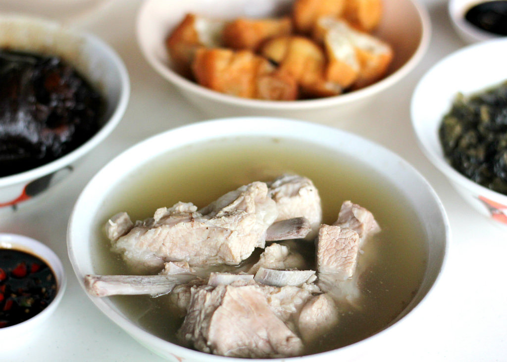

```python
url = "https://c1.staticflickr.com/1/544/32474665746_0a98a1e883_b.jpg"

from IPython.display import Image
Image(url, width ="600")
```

```python
match = {"$match":
         {"$or":[{"name": {"$regex":"k.+t teh", "$options": "-i"}},
          {"website": "http://www.songfa.com.sg/"}]
        }}
group = {"$group": {"_id": '$name', "count": {"$sum": 1}}}
sort = {"$sort": {'count': -1}}

pipeline = [match, group, sort]
run_aggregate_result(pipeline, db_sg)
```

```
{u'_id': {u'zh': u'\u677e\u53d1\u8089\u9aa8\u8336'}, u'count': 2}
{u'_id': u'bak kut teh', u'count': 1}
{u'_id': u'Ya Hua Bah Kut Teh Eating House', u'count': 1}
{u'_id': u'Eunos (Mrt) Bak Koot Teh', u'count': 1}
{u'_id': u'Ah Tou Seafood Bok Kat Teh', u'count': 1}
{u'_id': u'Lau Rock Guan Kee Bak Kut Teh', u'count': 1}
{u'_id': u'Legendary Bak Kut Teh', u'count': 1}
{u'_id': u'Leong Kee Bak Kut Teh', u'count': 1}
{u'_id': u'Swis Ling Bak Kut Teh Seafood Restaurant', u'count': 1}
{u'_id': u'Shi Wah Bat Kut Teh', u'count': 1}
{u'_id': u'Rong Hua Bak Kut Teh', u'count': 1}
{u'_id': u'Soon Soon Heng Bak Kut Teh', u'count': 1}
{u'_id': u'Xin Mei Le Bak Kut Teh', u'count': 1}
{u'_id': u'Yong Bak Kut Teh', u'count': 1}
{u'_id': u'Ah Long Bak Kut Teh (\u70eb\u9c7c)', u'count': 1}
```

```python
print u'\u677e\u53d1\u8089\u9aa8\u8336'
```

```
松发肉骨茶
```

#### Findings Bak Kut Teh Conclusion

So it seems that the OSM data was maintained and was able to easily find the first two restaurants but had a bit of difficulty in finding the third one. It appears that the name was only captured in Unicode / Mandarin, 松发肉骨茶 , so I wasn't able to match it using the English name. But an additional attribute in the form of the website was given so I was still able to find it.

However on further checking across the website of each of the three restaurants above, we can see that the data may not be the latest. For example, we can see that there's two outlets already shown for Rong Hua Bak Kut Teh http://www.ronghua.com.sg/contact-us.html, but we're only able to get one address from the query. This appears to be also the case for the Legendary/Founder Bak Kut Teh, http://legendarybkt.com/ where there are also two outlets listed on their website vs one address found on the OSM dataset. And finally a larger mismatch for the most popular Song Fa which already have seven outlets in Singapore, http://www.songfa.com.sg/outlets.html but we're only able to find two in the OSM dataset.

### Data Improvements

As this dataset consists of data from a neighbouring country, the first step of removing those nodes or ways by using the postal code format will work as a first layer. But we need additional help in identifying those nodes or ways in the dataset which are without the postal code format.

One cool improvement would be to have the OSM data entry page to allow for postal code auto street information look up, or any form of auto complete which could make the basic information such as street name or postal code to be populated upon entry, or include some basic validation to ensure basic fields are included to ensure that the data is more complete and easier to be use in query.

We saw that the house number 58 was entered by user JaLooNz which is also the top contributor which a record submission of 432,863 out of the total documents 2,041,233, that's around 20% of the dataset. And if this user tends to have a quick edit approach towards the data maintenace then that would largely affect the quality of the rest of the data set.

Another suggestion would be to have additional mobile app support which could allow the user to check into a particular location or start mapping upon app activation. Riding on the popularity of the app such as Pokemon Go, a simple app which allows the user to map a particular area and complete a goal, let's say a walking goal would be rather useful in allowing an accurate mapping of incomplete nodes or ways. The check in feature can also be useful in identifying point of interests, or restaurants which can lead to be more quality data set.

Due to the more complicated nature of searching names using unicode in MongoDB instead of plain English, I would also like to suggest that perhaps the English name would be needed by default and allow the Unicode version of the name to included as a secondary name.